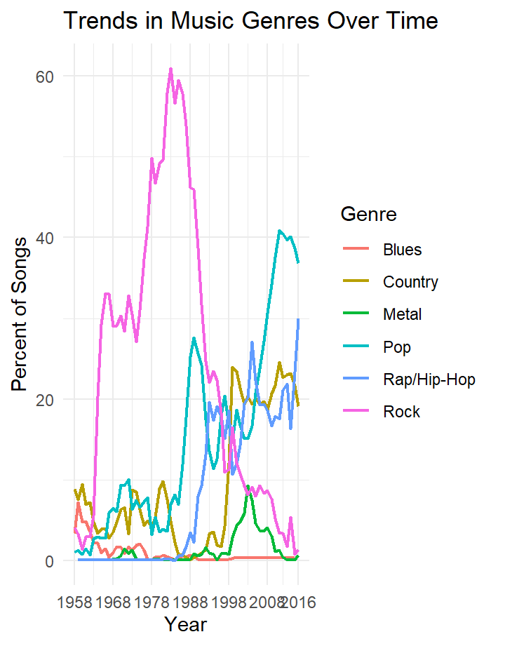

# Introduction

In this project, I will look into the evolution of music, specifically the rise and fall of the 6 most popular genres. I will be investigating how different time periods were associated with certain genres and how these genres rose to popularity and died out.

### Genres

- Blues
- Country
- Rock
- Metal
- Pop
- Hip-Hop

# Research Questions

- How has the popularity of different music genres changed from 1958-2016
- What factors contributed to the decline or rise of each genre
- What patterns arise in this rise or fall of genres such as politcal events, the popularity of instruments such as the electric guitar and digital sound

# Motivation Behind The Study

The motivation behind this project stems from a facination of music from all time periods as well as being a musician who has played and performed music from the time periods, and by analyzing the data from this, I will be able to better understand these genres that I have come to love as well as how some of my favorite bands and artists came into popularity

# Methods I Used to Clean and Organize the Data

Imported the dataset using read.csv() and set stringsAsFactors = FALSE to avoid automatic conversion of strings to factors.

Renamed columns with dplyr::rename() to make the variable names more concise and easier to work with: - Year.of.Date → Year - Primary.Genre → Genre - Percent.of.Songs → Percent

Removed percentage symbols from the Percent column using gsub(“%”, ““, Percent) and converted the values to numeric type for plotting and calculations.

Converted the Year column to integers using as.integer() to ensure the data is properly recognized as a continuous time variable.

Customized the x-axis using scale_x_continuous() to display breaks every 10 years and include the final year explicitly, improving readability.

# Data

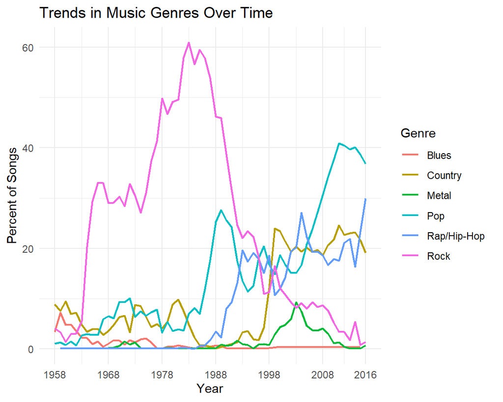

### Blues

Blues music was birthed during the 1920’s, which is often referred to as the Roaring Twenties. The Blues drew direct inspiration from traditional African style music as well as African-Americans from the deep south.

During the 1930’s, the Great Depression created extreme hardship which was reflected in the music with themes such as poverty and struggle. This time period birthed artists such as Robert Johnson, who is often considered one of the greatest blues artists of all time.

The 1940’s and 50’s gave way to what is considered to be the Golden Age of blues, with its popularity peeking at 7.2% of all Billboard hot 100 songs being blues in 1959.

After this Golden Age, blues music started to slowly down but from it’s influence, rock and roll began to emerge with bands such as The Rolling Stones, The Beatles, and Led Zeppelin drawing heavy influence into their songs and even covering old blues songs from the 1930’s and 40’s. Although blues wasn’t as popular, artists such as B.B. King and Albert King continued to play the blues and influence artists from all genres to this day.

During the late 1970’s is when blues started to really fall from the mainstream with 2.1% in 1975 and less than 1% every year since 1977.

Even though blues fell from mainstream it still is played to this day with a massive following that still enjoys the music

### Country

Country music began gaining popularity in the 1920’s when the Grand Ole Oprey started to play country music on the radio on November 28th, 1925. But in 1929 when the Great Depression hit America, no one had the extra money to spend on records which cause country music to plateau in terms of popularity.

During World War II, the USO (United States Organization) brought country music to a global audience. During this time, country music also exploded within America with well known artists such as Johnny Cash, Dolly Parton, and Willie Nelson emerging. This period continued into the 80s, with country music’s popularity on the Billboard charts ranging from 3-10% depending on the year.

Country music in the 1970’s and 80’s changed country music forever with the usage of new technology such as the electric guitar gaining gaining extreme popularity, this led to the 1990’s which is often considered the golden age of country.

In the 90s, many artists adopted a “hat act”, which is essentially country artists just wearing a cowboy hat and calling the new sound they were playing country. Artists like Garth Brooks and Billy Ray Cyrus, brought country mainstream with its popularity peeking at 24% of all songs in 1999 on the Billboard hot 100 charts being categorized as country.

Country music has continued to ride this popularity to the modern day with a popularity of around 20% depending on the year.

### Rock

Post World War II, a cultural blend of blues, country, and jazz formed into a genre of music known as Rock and Roll. Iconic figures of this genre were people such as Elvis Presley and Chuck Berry. By 1960, Rock and Roll had taken up 31.2% of the Billboard charts.

During the 1960’s, Rock and Roll music started to form into the wider genre we know today as “Rock” music with the British Invasion, led by bands such as The Rolling Stones and The Beatles which revolutionized the sound of rock music. Bands such as Pink Floyd and the Jimi Hendrix Experience formed in the late 1960’s under a sub genre of rock music called Psychedelic rock which was indirectly caused by the drug LSD which had become very popular during this time period.

Music during this time period was marked by the Civil Rights Movement and activism. Bands such as The Beatles, Jimi Hendrix, and Bob Dylan made conscious efforts to write songs about these events which caused the genre to grow even more with Rock and Roll and Rock combined taking up 42.7% of the Billboard charts in 1964.

The 1970’s saw the expansion of rock through sub-genres such as Hard Rock, Heavy Metal, and Punk Rock. During this era, we also saw the start of songs stop being referred to as Rock and Roll and placed under the larger genre of Rock. In the 1970’s the band Led Zeppelin start to gain notoriety and is debated now as the biggest rock band of all time, in debate against The Beatles and by 1978, rock music took up 49.8% of the billboard charts.

The 1980’s saw another explosion of rock music with genres such as glam rock and alternative rock. The 1980’s also saw the rise of Michael Jackson who is often recognized as the biggest artist of all time. By 1983, rock music consisted of 60.9% of the billboard charts.

Since 1983, rock has slowly started to decline in popularity due to genre’s such as Country, R&B, and Hip Hop becoming more popular. Despite this, rock music is still enjoyed to this day from all decades and age groups.

### Metal

Heavily metal fans widely agree that it was born in 1968-1970 with the bands Led Zeppelin, Black Sabbath, and Deep Purple. Heavy metal came from standard blues rock which was largely popular in the 1960’s and was defined by a heavy sound (usually meaning high volume songs with heavy distortion).

Among these 3 bands, Black Sabbath is often referred to as the band that started this genre. The band’s guitarist suffered a industrial accident that caused part of his finger to be cut off, and as a result of this he was forced to tune his guitar down so that the strings would be easier to press down and play chords with simple fingerings.

Although these bands were very popular, a lot of their music was still seen as blues rock or hard rock so in 1971 only 1.5% of the songs on the Billboard charts were recognized as “metal.”

Metal really started to kick off when the band Metallica formed in 1983, creating songs with heavy bass riffs and the usage of the double kick bass drum, this sparked a bunch of sub-genres such as Thrash Metal and Death Metal.

In the early 1990’s, a hybrid genre emerging from Seattle, WA consisting of elements punk + metal known as “grunge” formed, this helped to greater launch heavy forms of music into the mainstream with bands such as Nirvana and Pearl Jam.

Bands such as Korn and Slipknot formed under the sub-genre of “Nu Metal” which was launched into the mainstream in the late 1990’s and early 2000’s with 9.3% of Billboard songs being in the metal category in 2003.

Metal slowly started to decline in popularity after this time for the same reasons that rock did but like blues and rock, there is still a huge following for heavy metal music to this day.

### Pop

Pop Music is a phrase that refers to the popular style of music at the time and broad appeal.

During the 1950’s and 1960’s, the pop music we know today wasn’t the same as it was listed under the name Pop Standards with stars such as Frank Sinatra representing the genre. During this time pop standards was extremely popular, representing 41.7% of the billboard charts when they came out in 1958.

During the 1970’s and 80’s, genres such and funk were very popular with artists such as James Brown and Stevie Wonder. This gave way to what we recognize today as pop rock such as Elton John and bands like Queen.

During this time, digital equipment such as synthesizers an digital drums gave way to genres like disco music. By 1989, pop music that we know today took up 27.6% of the billboard charts in a very rock dominated era. But as rock started to fall, pop music surged in popularity.

Pop music today is dominated by catchy songs and songs that you are likely to hear on the radio and has kept its popularity, making up of around 40% of the billboard charts every year since 2011.

### Rap/Hip-Hop

In the Bronx in the 1970’s, block parties were a very popular means of people coming together. Here, a block party equipped with powerful speakers turned on traditional funk and disco music but used break beats to sample the drums and essentially rap on top of it.

In 1979, The Sugarhill Gang released Rapper’s Delight, which was the first hip-hop song to reach the mainstream, at this time Hip-hop was only charting less than 0.1% of songs.

In 1984, a student from New York named Rick Rubin set up his own record production company from his dorm called Def Jam records. Rubin in the time was in a punk band but shifted towards hip-hop and released his very single “I Need a Beat” by LL COOL J.

By the 1990’s, hip-hop had became a huge business where East Coast and West Coast rappers clashed, led by the Rivalry of Tupac Shakur and Biggie Smalls’. By 1993 hip-hop consisted of 19.3% of the billboard charts. These two were murdered in 1996 and 1997 and although these incidents were tragic, they brought an unimaginable amount of attention to both of these rappers and the music that they had produced and in 2004, hip-hop’s popularity jumped up to 27.1%.

Modern rap has gained massive popularity especially with young adults. Artists such as Drake, Kendrick Lamar, and Future have brought new listeners to the scene with the use of their samples, featuring on other songs, and catchy lyrics. In 2016, Rap/Hip-hop consisted of 30.0% of all billboard charts and is on its way up.

# Works Cited

Admin. “Rock Music Through the Decades.” Novecore Blog, 25 Jan. 2024, blog.novecore.com/rock-music-through-the-decades.

Beckwith, Jack. “The Evolution of Music Genre Popularity | the Dataface.” Thedataface.Com, thedataface.com/2016/09/culture/genre-lifecycles. Accessed 7 May 2025.

“Blues Music History: The Influence of Blues Music from the 1920’s to 2000’s - Blues Chronicles.Com.” Blues Chronicles.Com - Journey Into The Blues, 9 July 2023, blueschronicles.com/blues-music-history-the-influence-of-blues-music-from-the-1920s-to-2000s/.

“Heavy Metal Music: A Rough Timeline — BobThune.com.” BobThune.com, 27 Dec. 2023, www.bobthune.com/blog/2020/02/heavy-metal-music-a-rough-timeline.

Heritageherald. “The History of Country Music.” The Heritage Herald, 14 Mar. 2024, heritageherald.com/2024/03/14/the-history-of-country-music.

Joubert, Stefan. “Evolution of Pop Music | London Singing Institute.” London Singing Institute, 12 Aug. 2020, www.londonsinginginstitute.co.uk/evolution-of-pop-music.

Life, Sound Of. “Celebrating 50 Years of Hip-Hop: A Timeline of the Music Genre’s Iconic Moments | Sound of Life | Powered by KEF.” Sound of Life, www.soundoflife.com/blogs/mixtape/hip-hop-history-timeline.

Opry. “HOW THE 1990S SHAPED COUNTRY MUSIC FOREVER | Opry.” Opry, www.opry.com/stories/country-by-the-decade-1990s#:~:text=The%201990s%20was%20a%20golden,caught%20the%20line%2Ddancing%20bug.